# tf-func-scope

Fateema Bazzi

2025-01-05

# Project Description

In this project, I analyzed the variability of functional categories of the targets of transcription factors.

# Libraries

```r
library(tidyverse)
```

```r
library(dplyr)
library(ggplot2)
library(tidyr)
```

# Data Sources

Here I load in the genes and their associated COGS

```r
gene_func_cat <- read.csv("E_coli_data/annotations/cog-24_Ecoli.cog.csv", header = FALSE)
gene_func_cat <-gene_func_cat[,c(1,7)]
head(gene_func_cat)
```

```
##      V1      V7
## 1 b0154 COG0001
## 2 b3958 COG0002
## 3 b0451 COG0004
## 4 b2407 COG0005
## 5 b2385 COG0006
## 6 b2908 COG0006
```

Here I load in a table mapping each COG to a functional category

```r
cog_to_func_cat <- read.table("E_coli_data/annotations/cog-24.def.tab", sep = "\t")
cog_to_func_cat <- cog_to_func_cat[,1:2]
head(cog_to_func_cat)
```

```
##        V1 V2
## 1 COG0001  H
## 2 COG0002  E
## 3 COG0003  P
## 4 COG0004  P
## 5 COG0005  F
## 6 COG0006  E
```

Here I load in data linking transcription factors to their targets.

```r
reg_net <- read.table("network_tf_gene_Ecoli_GRN.txt", skip=37, sep="\t")
reg_net <- reg_net[,c(2,4)]
colnames(reg_net)<- c("TF", "Target")
reg_net[,1]<-tolower(reg_net[,1])
reg_net[,2] <- tolower(reg_net[,2])
head(reg_net)
```

```
##     TF Target
## 1 aaer   aaea
## 2 aaer   aaeb
## 3 aaer   aaex
## 4 accb   accb
## 5 accb   accc
## 6 acrr   acra
```

Here I load in data mapping gene names to bnumbers

```r
id_to_bid <- read_tsv("GeneProductSet.txt", skip=41, col_names = FALSE)
id_to_bid <- id_to_bid[,2:3]
colnames(id_to_bid) <- c("name","bnumber")
id_to_bid$name <- tolower(id_to_bid$name)
head(id_to_bid)
```

```
## # A tibble: 6 × 2
##   name  bnumber
##   <chr> <chr>
## 1 thrl  b0001
## 2 thra  b0002
## 3 thrb  b0003
## 4 thrc  b0004
## 5 yaax  b0005
## 6 yaaa  b0006
```

# Functional category preprocessing

## Add Functional Categories to Genes

Using the COGs, I associate each gene with a functional category. Those without an association are ommitted.

```r
# Rename columns for clarity
colnames(cog_to_func_cat) <- c("COG", "funccat")
colnames(gene_func_cat)[2] <- "COG"  # Assuming the 2nd column has the COG values

# Merge by "COG" to map functional categories, preserving all rows in gene_func_cat
gene_func_cat <- merge(gene_func_cat, cog_to_func_cat, by = "COG", all.x = TRUE)

#exclude genes with no associated functional category
gene_func_cat <- na.omit(gene_func_cat)

# Display the first few rows
head(gene_func_cat)
```

```
##       COG    V1 funccat
## 1 COG0001 b0154       H
## 2 COG0002 b3958       E
## 3 COG0004 b0451       P
## 4 COG0005 b2407       F
## 5 COG0006 b2908       E
## 6 COG0006 b3847       E
```

## Remove duplicate rows

Some genes are listed more than once, so I remove duplicates. Duplicates are considered rows with the same gene and functional category, not necessarily the same COG.

```r
gene_func_cat <- gene_func_cat[!duplicated(gene_func_cat[,2:3]),]
```

# Regulatory Network Preprocessing

## Switch to bnumbers

Here I change the target gene names to their associated bnumbers

```r
# Temporarily rename column
colnames(reg_net)[2] <- "name"

# Merge by "ID"
reg_net <- merge(reg_net, id_to_bid, by = "name", all.x = TRUE)

#exclude genes with no associated bnumber
reg_net <- na.omit(reg_net)

#drop the old ids and rename appropriately
reg_net <- reg_net[,2:3]
colnames(reg_net)[2] <- "Target"

head(reg_net)
```

```
##     TF Target
## 1 aaer  b3241
## 2  crp  b3241
## 3  crp  b3240
## 4 aaer  b3240
## 5  crp  b3243
## 6  crp  b3242
```

Here I change the transcription factor gene names to their associated bnumbers

```r
#repeat for the TFs
# Temporarily rename column
colnames(reg_net)[1] <- "name"

# Merge by "ID"
reg_net <- merge(reg_net, id_to_bid, by = "name", all.x = TRUE)

#exclude genes with no associated bnumber
reg_net <- na.omit(reg_net)

#drop the old ids and rename appropriately
reg_net <- reg_net[,2:3]
colnames(reg_net)[2] <- "TF"

# Display the first few rows
head(reg_net)
```

```
##   Target    TF
## 1  b3241 b3243
## 2  b3242 b3243
## 3  b3240 b3243
## 4  b3255 b3255
## 5  b3256 b3255
## 6  b0464 b0464
```

## Remove Duplicates

Remove rows with the same target and transcription factor.

```r
reg_net <- reg_net[!duplicated(reg_net),]
```

## Reformat the network table and keep only TFs with >20 targets

I look at transcription factors with a larger number of targets to ensure robust diversity calculations.

```r
reg_net_final <- list()
i=1
for (tf in names(which(table(reg_net$TF)>20))){
  targets<-reg_net[which(reg_net$TF==tf),1]
  func_cats <- list()
  j=1
  for (targ in targets){
    func_cats[[j]] <- gene_func_cat[which(gene_func_cat$V1 == targ),3]
    j=j+1
  }
  reg_net_final[[i]]<- list(TF=tf, Category=unlist(func_cats))
  i=i+1
}
```

The result is a list of functional categories of the targets for each transcription factor.

After getting the associated functional categories, some genes did not have an associated category, so I check once again that each transcription factor has more than 20 targets.

```r
reg_net_final <- reg_net_final[unlist(lapply(reg_net_final, function(x) length(x$Category)>20))]
```

# Calculate Category Weights

I weight the functional categories in order to incorporate the overall frequency of each category in the genome to adjust for biases in the dataset.

```r
#raw weights
raw_weights <- table(gene_func_cat$funccat)/length(gene_func_cat$funccat)
#normalized
weights <- raw_weights/sum(raw_weights)
```

# Calculate functional diversity

I use entropy to measure how spread out the functional categories are within a transcription factor’s target set.

```r
entropies=list()
i=1
for (tf in reg_net_final){
  entropy=0
  for (cat in names(table(tf$Category))){
    pi=table(tf$Category)[cat]/sum(table(tf$Category))
    entropy=entropy+(weights[cat]*(pi*log(pi)))
  }
  entropy=entropy*-1
  entropies[[i]]=list(TF=tf$TF, entropy=unname(entropy))
  i=i+1
}
```

# Results Analysis and Visualization

First, I use a bar plot to show the functional category distributions for individual transcription factors. It can be seen that some transcription factors have much more targets belonging to certain functional categories than others.

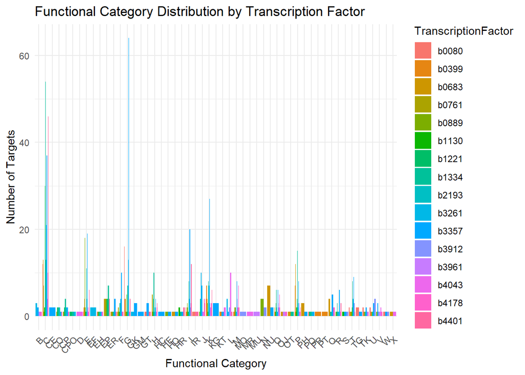

```r
#flatten list into dataframe
reg_net_df <- do.call(rbind, lapply(reg_net_final, function(x) {
  data.frame(
    TranscriptionFactor = x[[1]],
    FunctionalCategory = x[[2]]
  )
}))

# Count occurrences of each functional category for each transcription factor
long_form_df <- reg_net_df %>%
  group_by(TranscriptionFactor, FunctionalCategory) %>%
  summarise(Count = n(), .groups = "drop")

# Create a bar plot
ggplot(long_form_df, aes(x = FunctionalCategory, y = Count, fill = TranscriptionFactor)) +
  geom_bar(stat = "identity", position = "dodge") +
  labs(
    title = "Functional Category Distribution by Transcription Factor",
    x = "Functional Category",
    y = "Number of Targets"
  ) +
  theme_minimal() +
  theme(axis.text.x = element_text(angle = 45, hjust = 1))
```

Next, I plot entropy values for all transcription factors in an attempt to highlight trends or outliers. However, the graph shows that there are no outliers in the calculated entropy values.

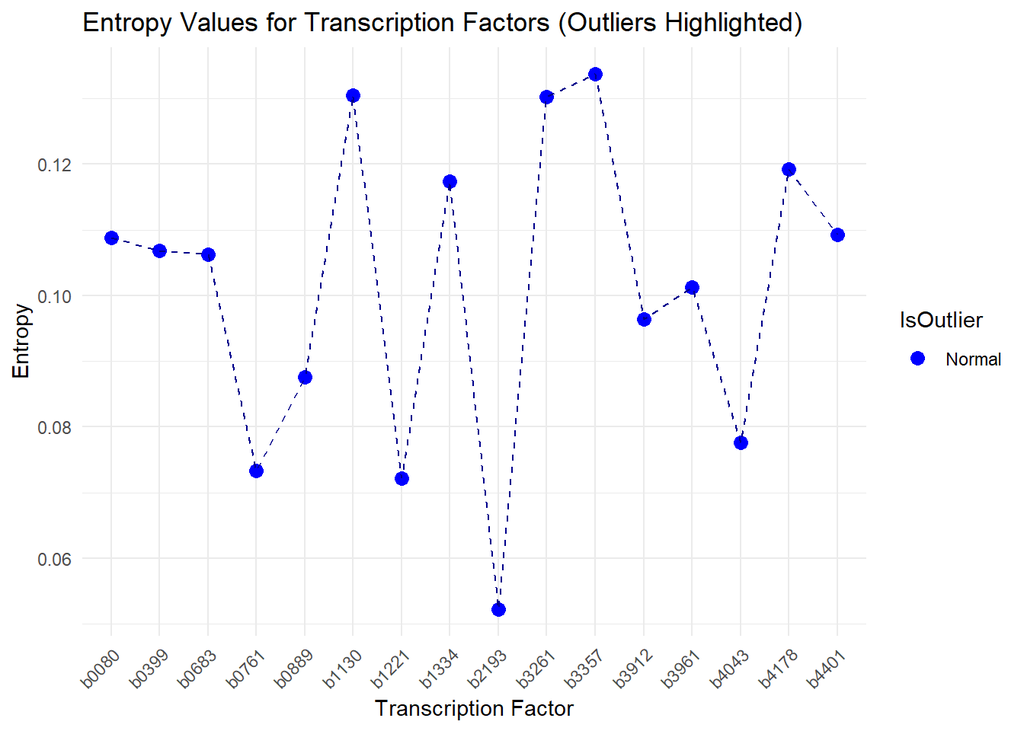

```r
#flatten list into dataframe
entropies_df <- do.call(rbind, lapply(entropies, function(x) {
  data.frame(
    TranscriptionFactor = x[[1]],
    Entropy = x[[2]]
  )
}))

mean_entropy <- mean(entropies_df$Entropy)
sd_entropy <- sd(entropies_df$Entropy)
threshold <- mean_entropy + 2 * sd_entropy

# Add a column to classify outliers
entropies_df <- entropies_df %>%
  mutate(IsOutlier = ifelse(Entropy > threshold, "Outlier", "Normal"))

# Plot with highlighted outliers
ggplot(entropies_df, aes(x = TranscriptionFactor, y = Entropy)) +
  geom_point(aes(color = IsOutlier), size = 3) +
  geom_line(group = 1, color = "darkblue", linetype = "dashed") +
  scale_color_manual(values = c("Normal" = "blue", "Outlier" = "red")) +
  theme_minimal() +
  labs(
    title = "Entropy Values for Transcription Factors (Outliers Highlighted)",
    x = "Transcription Factor",
    y = "Entropy"
  ) +
  theme(axis.text.x = element_text(angle = 45, hjust = 1))
```

I use a heatmap to visualize category distributions for targets of each transcription factor.

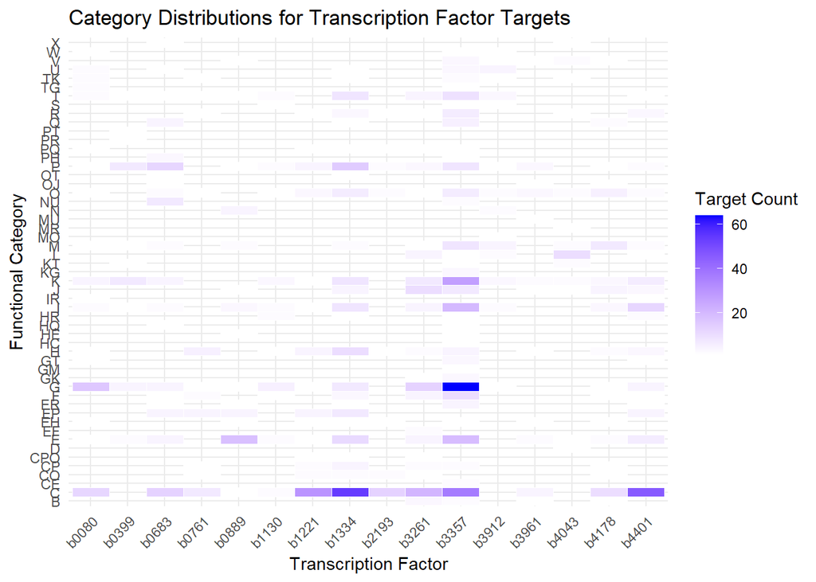

```r
# Heatmap plot
ggplot(long_form_df, aes(x = TranscriptionFactor, y = FunctionalCategory, fill = Count)) +
  geom_tile(color = "white") +
  scale_fill_gradient(low = "white", high = "blue") +
  labs(
    title = "Category Distributions for Transcription Factor Targets",
    x = "Transcription Factor",
    y = "Functional Category",
    fill = "Target Count"
  ) +
  theme_minimal() +
  theme(axis.text.x = element_text(angle = 45, hjust = 1))
```

This bar chart shows the relative contributions of categories to entropy, showing how some categories contribute more to specific transcription factors than others.

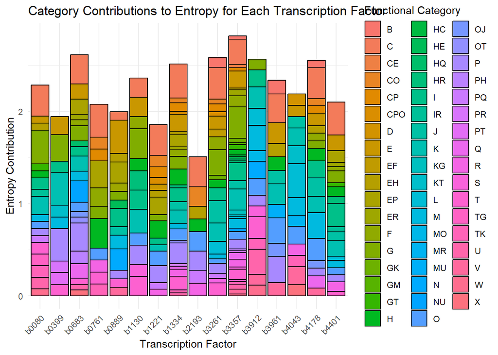

```r
# Calculate proportions and entropy contributions
entropy_contributions <- long_form_df %>%
  group_by(TranscriptionFactor) %>%
  mutate(
    Total = sum(Count),
    Proportion = Count / Total,
    EntropyContribution = -Proportion * log(Proportion)
  ) %>%
  ungroup()

# Stacked bar chart for entropy contributions
ggplot(entropy_contributions, aes(x = TranscriptionFactor, y = EntropyContribution, fill = FunctionalCategory)) +
  geom_bar(stat = "identity", color = "black") +
  labs(
    title = "Category Contributions to Entropy for Each Transcription Factor",
    x = "Transcription Factor",
    y = "Entropy Contribution",
    fill = "Functional Category"
  ) +
  theme_minimal() +
  theme(axis.text.x = element_text(angle = 45, hjust = 1))
```

I produced a histogram of the entropy values as an attempt to reveal whether the distribution is skewed or uniform.

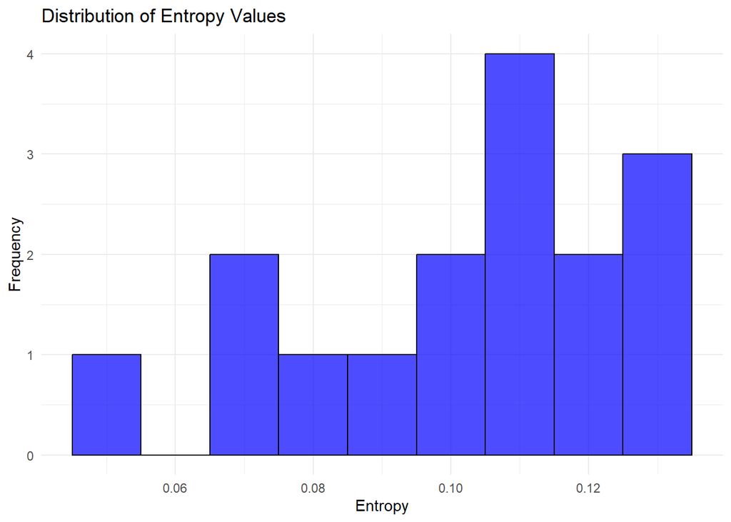

```r
# Histogram of entropy values
ggplot(entropies_df, aes(x = Entropy)) +
  geom_histogram(binwidth = 0.01, fill = "blue", color = "black", alpha = 0.7) +
  labs(
    title = "Distribution of Entropy Values",
    x = "Entropy",
    y = "Frequency"
  ) +
  theme_minimal()
```

Finally, I produced a scatterplot of entropy versus the number of targets to help visualize whether transcription factors with more targets exhibit higher entropy. The plot implies that a larger number of targets is associated with a higher entropy, but the association is not strong.

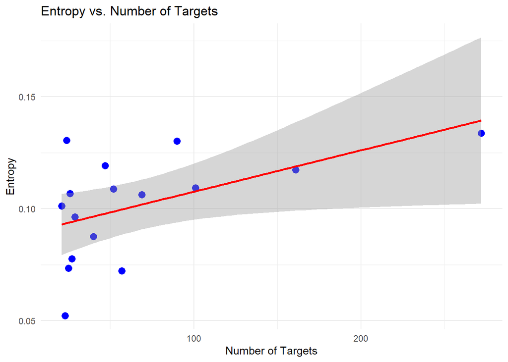

```r
# Reshape to wide form using dcast() or pivot_wider
category_counts_wide <- long_form_df %>%
  pivot_wider(names_from = FunctionalCategory, values_from = Count, values_fill = list(Count = 0))

# Merge the dataframes based on TranscriptionFactor
combined_df <- merge(entropies_df, category_counts_wide, by = "TranscriptionFactor")

# Calculate the total number of targets for each transcription factor
combined_df$NumTargets <- rowSums(combined_df[ , 4:56])  # Summing all category counts

# Scatterplot of Entropy vs. Number of Targets
ggplot(combined_df, aes(x = NumTargets, y = Entropy)) +
  geom_point(size = 3, color = "blue") +
  geom_smooth(method = "lm", se = TRUE, color = "red") +
  labs(
    title = "Entropy vs. Number of Targets",
    x = "Number of Targets",
    y = "Entropy"
  ) +
  theme_minimal()
```

# Conclusions

After using entropy calculations to assess how variable the functional categories of targets of transcription factors are, I found that while none of the entropy values hit an extreme, the values overall displayed low variability of the functional categories of the targets. This may imply that the transcription factors are relatively specialized, and many of their targets share a similar function. One limitation of that data to be considered is that after limiting the analysis to transcription factors with more than 20 targets, there were only 16 transcription factors. With a larger list or a more lenient constraint, I may have been able to observe greater variability in the overall range of entropies across transcription factors.